# Agentic AI for *Biomedical Data Science*

Hands-on portion

Alex Pickering

Senior Developer

Core for Computational Biomedicine (CCB)

# A Framework to Manage Context and Improve Results

Research

Collect relevant facts in research.md

Plan

Use research to create phased plan. Review fully and refine.🧑‍🔧

Execute

Make it work, then make it right.

Reflect

Read the output.🧑‍🔧

- **New chat sessions for each phase**: clears irrelevant information to improve model performance
- **Mirrors engineering and project-management workflows:** drives high-quality results

# Do cholesterol-lowering drugs reduce the risk of *dementia*?

Reproducing a published paper with **Claude Code**

Nordestgaard LT, Hanson A, Sanderson E, et al. **Cholesterol-lowering drug targets reduce risk of dementia: Mendelian randomization and meta-analyses of 1 million individuals.** *Alzheimer’s & Dementia* 2025;21:e70638. doi:10.1002/alz.70638

The destination

# Mendelian randomisation gets causal evidence from observational data

[figure not shown]

- If we know both effects — alleles on LDL, alleles on dementia — in the **same individuals**: **One-sample MR**
- If we know each effect from a **different study**: **Two-sample MR**

The destination

# Variants in targets of cholesterol-lowering drugs reduce dementia risk

The paper's one-sample arm(UK Biobank, individual-level)

The destination

# The two-sample arm is what we can reproduce

The paper's two-sample arm(GLGC → CCHS+CGPS, UKB, FinnGen)

How it was built

# A Framework to Manage Context and Improve Results

Research

Collect relevant facts in research.md

Plan

Use research to create phased plan. Review fully and refine.🧑‍🔧

Execute

Make it work, then make it right.

Reflect

Read the output.🧑‍🔧

1 · Research

# Ask for facts, not opinions

neuroprotective_lipid_genes — Claude Code

ALZ-21-e70638.pdf

Claude Code

*read this paper and generate a research.md file with notes. The notes should only include facts that are relevant* to reproduce this paper's approach using the datasets that can be publically downloaded without request. *Do not include opinions on how to implement the approach.*

+/ Bypass permissions

1 · Research **research.md**

neuroprotective_lipid_genes — Claude Code

ALZ-21-e70638.pdfresearch.md

*#*Reproducing the LDL-lowering to dementia analysis

⋮

*##*Datasets and releases

GLGC 2021 — variant to LDL cholesterol

FinnGen R12 — variant to dementia

…

*##*Choosing the variants

a window around each drug-target gene

…

*##*How the estimate is calculated

…

*##*The paper's own estimates

…

1 · Research **research.md**

# Two of five datasets are obtainable

| Dataset | Status |
| --- | --- |
| UK Biobank | application required |
| Copenhagen ×2 | cannot be shared |
| GLGC | open — variant → cholesterol |
| FinnGen | open — variant → disease |

1 · Research **research.md**

- **Details of approach** — six drug-target genes, non-HDL cholesterol, four dementia endpoints, heart disease as the positive control
- **Data location and release** — GLGC without UK Biobank, FinnGen
- **How to choose the variants** — the window around each gene, the paper's own rsIDs
- **How the estimate is calculated**
- **The paper's estimates to compare against** — for heart disease (positive control) and dementia

2 · Plan **plan.md**

# Ask for a phased plan based on research

neuroprotective_lipid_genes — Claude Code

ALZ-21-e70638.pdfresearch.md

Claude Code

*read research.md and come up with a phased plan.md* file to reproduce the two-sample MR approach. Phases should be first to *“make it work”* then to *“make it right”*. Ask me about open questions so that we achieve alignment on the plan before any implementation.

+/ Bypass permissions

2 · Plan **plan.md**

# We settled on four phases

neuroprotective_lipid_genes — Claude Code

plan.mdPreview plan.md

Plan — reproducing the two-sample arm

…

Phases

| Phase | Goal | Done when |
| --- | --- | --- |
| 0 · acquire | get the data | six gene regions cached, both sources |
| 1 · make it work | works end to end | 6 genes × 2 diseases, use rsIDs |
| 2 · make it right | the paper's real method | our own variants, 5 diseases, assumption checks |
| 3 · stretch | optional extension | more Alzheimer's cases |

3 · Execute **Plan phases 0–2** · make it work, then make it right

# Review plan carefully before implementation

Alex

Proceed with the phased implementation in plan.md

Claude

- **Phase 0** — fetched the six gene regions only: ~10 MB, not 5 GB of whole-genome files
- **Phase 1** — six genes × two diseases, heart-disease check passing
- **Phase 2** — picked its own variants, five diseases, alternative estimators, assumption checks

3 · Execute **Plan phase 1** · make it work

# Heart disease as a positive control

This reproduction(GLGC → FinnGen) The paper(GLGC → CCHS+CGPS, UKB, FinnGen)

The destination

# Our reproduction, against the paper's two-sample arm

This reproduction(GLGC → FinnGen) The paper's two-sample arm(GLGC → CCHS+CGPS, UKB, FinnGen)

4 · Reflect

# Should we include UK Biobank participants in GLGC?

Alex

Since we are not using uk biobank, does it make sense to use GLGC release that includes uk biobank participants?

Claude

- **Argued to use release that excludes UK Biobank**
- Interval widths are driven by the low dementia numbers
- Introduces bias if we add a dementia dataset that includes UK Biobank participants

4 · Reflect

# Asking what would actually move the result

Alex

what is the easiest database to get access to to increase outcome numbers?

Claude

- **OpenGWAS** — already readable by the tools we were using
- ~39,000 Alzheimer's cases against our 6,000

3 · Execute **Plan phase 3** · the extension

# More cases, and what they moved

Alex

lets proceed with opengwas

Claude

| ANGPTL4 → Alzheimer's | 6k cases | ~45k cases |
| --- | --- | --- |
| Odds ratio (95% CI) | 2.56 (0.88–7.44) | 2.62 (1.38–4.95) |

Odds of Alzheimer's per 1 SD lower cholesterol through this target.

4 · Reflect **Plan phase 3** · reading the result

# "Not significant" is two different results

Claude

"... the remaining nulls are a power story ..."

Alex

but didn't we add a lot of cases from opengwas so the power should be good no?

Claude

Conceded — for Alzheimer's that is no longer true:

| Target → outcome | Cases | Odds ratio (95% CI) |  |
| --- | --- | --- | --- |
| CETP → Alzheimer's | 6,100 | 0.82 (0.58–1.17) |  |
| CETP → Alzheimer's | 45,000 | 1.05 (0.88–1.25) |  |
| HMGCR → vascular dementia | 2,700 | 0.52 (0.13–2.11) |  |

3 · Execute **Plan phase 3** · the report

# The tool had instructions I had not found

Alex

put together a report.Rmd with background and details about our reproduction...

Claude

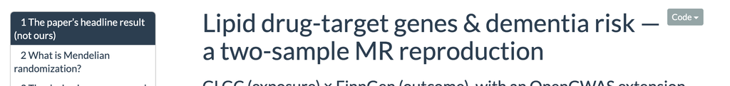

⋮

Alex

recreate the report using the *artifact-design and dataviz skills*

Claude

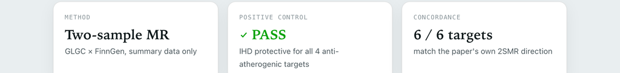

4 · Reflect **While making this deck** · the fact base was wrong

# Claude wrote down a limit that did not exist

In the notes

"unspecified dementia (ICD-10 F03) has no clean standalone R12 public endpoint"

Alex

wasn't FinnGen R12 used by the paper as well so shouldn't it be there?

Claude

- Listed all endpoints — **F5_DEMNAS** is unspecified dementia, ICD-10 F03
- Original search tried "UNSPEC" and "F03"
- Added it and re-ran

4 · Reflect **Plan phase 3** · the report

# Check all AI-generated text

- Insufficient background and assumed familiarity
- Too much detail on minor digressions from chat session
- Overly sensational or hyped language

In the report

“… the lone real divergence is CETP …”

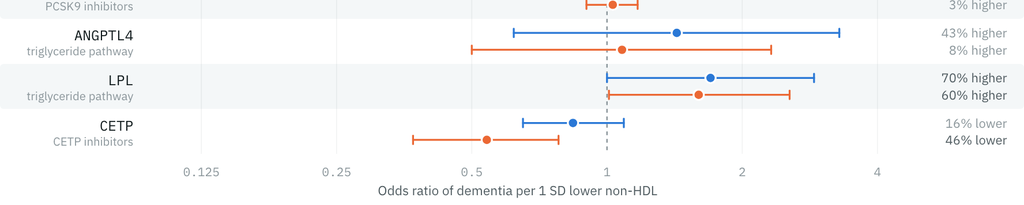

This reproduction The paper's two-sample arm

Should have used

Guidelines on generative AI

# Review content before publishing or sharing

> AI-generated content can be inaccurate, misleading, or entirely fabricated (sometimes called “hallucinations”) or may contain copyrighted material. **You are responsible for any content that you publish or share that includes AI-generated material.** — HUIT guidelines on generative AI

**HUIT** huit.harvard.edu/ai/guidelines **HMS IT** it.hms.harvard.edu/about/policies-and-guidelines/generative-ai-guidelines

Take-aways

# Methodology *>* prompts

- **Gather relevant facts into research.md** — the source of truth for the plan
- **Align on a phased plan.md** — review this manually
- **Implement the plan**
- **Reflect means critically reading the output**

Research Plan Execute Reflect